# Social Forecasting Tutorial 3

Martyn Egan

31/03/2023

# Data-driven Forecasting

Forecasting methods can be divided into model-based and data-driven methods. Model-based methods involve fitting data to a model, whose parameters have been estimated from the training period. Regression and autocorrelation-based models (including ARIMA) are model-based methods.

Data-driven methods, by contrast, use algorithms to “learn” patterns from the data. Naive forecasts are data-driven, as are smoothing methods, which are the main focus of today’s class. Moving averages can be used to “smooth” out the noise in a time series to uncover patterns. In general, data-driven methods are more useful for time series whose structure changes over time, or when model assumptions are likely to be violated.

## Moving Averages

A moving average is a simple smoother which averages time series values across a window (*w*) of consecutive periods.

- *Centred moving averages* are used to visualise trends, because the averaging suppresses the effects of seasonality and noise in the data.
- *Trailing moving averages* are used for forecasting: because we do not know values for future dates, the window is an average of prior values.

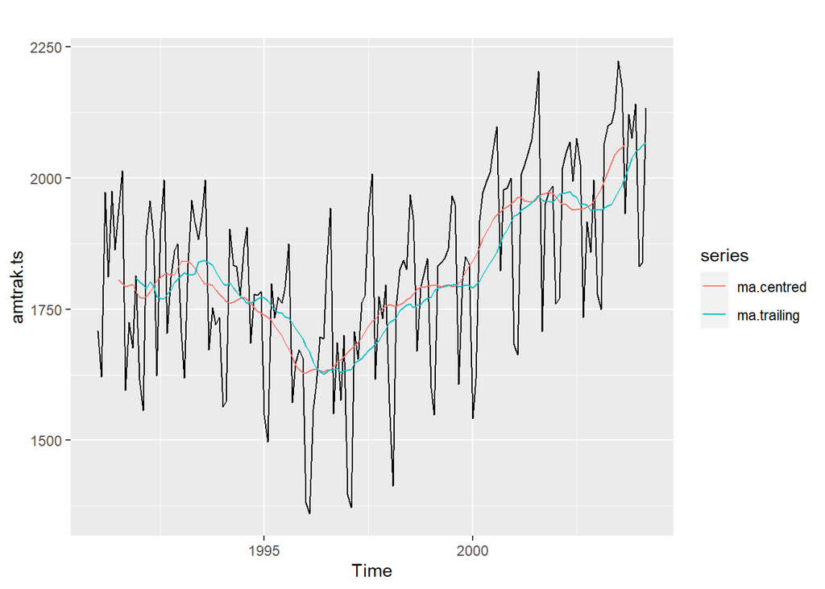

```r
amtrak <- read.csv("data/Amtrak.csv") #read in data
amtrak.ts <- ts(amtrak$Ridership, start = c(1991, 1), end = c(2004, 3), frequency = 12)

# the forecast package contains a function, ma(), for calculating centred moving averages
ma.centred <- ma(amtrak.ts,
                 order = 12 # this is the window argument
              )
# the zoo package contains a function, rollmean(), for calculating a trailing moving average
ma.trailing <- rollmean(amtrak.ts,
                        k = 12, # this is the window argument
                        align = "right" # this sets to trailing average
                        )
# we can plot these using autoplot() and autolayer(), which is less verbose than base plot
autoplot(amtrak.ts) +
  autolayer(ma.centred) +
  autolayer(ma.trailing)
```

Note: when used for forecasting, a trailing moving average of *w* = 1 will produce a naive forecast, while *w* = *n* (the length of the training period) will average over the entire training period. Moving average forecasts are necessarily horizontal lines.

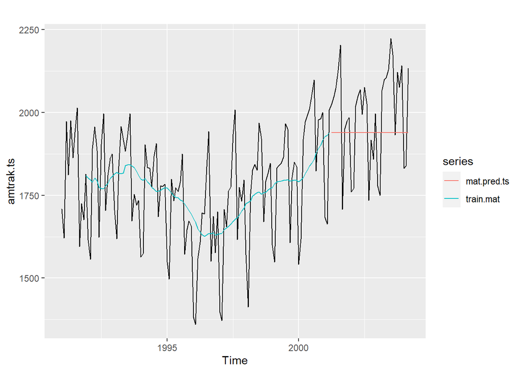

```r
train.ts <- window(amtrak.ts, end = c(1991, length(amtrak.ts) - 36))
train.mat <- rollmean(train.ts,
                      k = 12, # set window to 1 year
                      align = "right")
last.mat <- tail(train.mat, 1) # take the final value to forecast
mat.pred.ts <- ts(rep(last.mat, 36), # make ts of moving average forecast
                  start = c(1991, length(amtrak.ts) - 35),
                  end = c(1991, length(amtrak.ts)),
                  freq = 12)

autoplot(amtrak.ts) + # plot trailing moving average and forecast
  autolayer(train.mat) +
  autolayer(mat.pred.ts)
```

## Differencing (lag)

A method for removing a trend and/or seasonal pattern is through *differencing* or lagging the time series, i.e. taking the difference from two values.

- A lag-1 difference is the difference between two consecutive values. This will remove a linear trend (for quadratic or exponential trends, the process requires repeating, i.e. a lag-1 difference must be applied to the lag-1 difference.)
- A lag-k difference will remove seasonality, where *k* referes to the frequency, i.e. 7 for weekly, 12 for monthly, 4 for quarterly, etc.
- To remove both trend *and* seasonality, two lags must be applied.

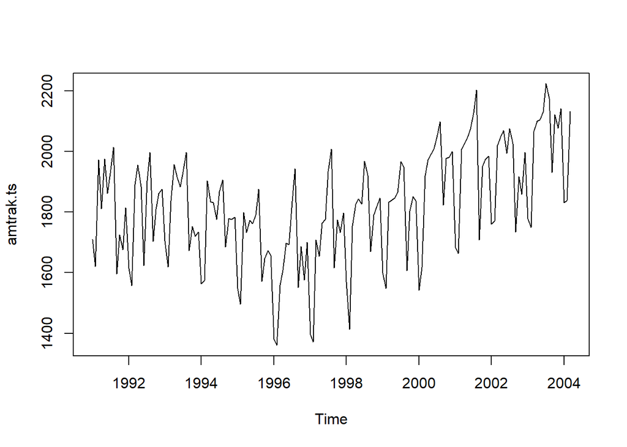

```r
# the diff() function performs lagging on data
plot(amtrak.ts)
```

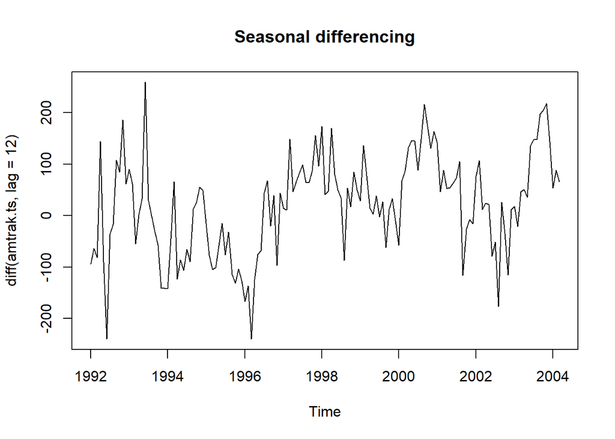

```r
plot(diff(amtrak.ts, lag = 12), main = "Seasonal differencing") # removes seasonality
```

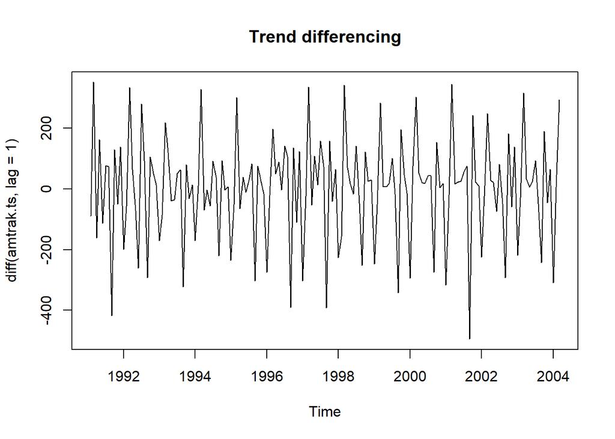

```r
plot(diff(amtrak.ts, lag = 1), main = "Trend differencing") # removes a linear trend
```

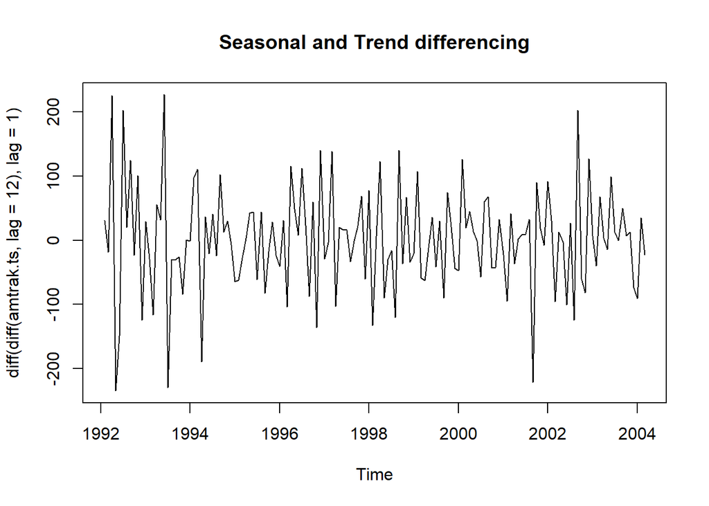

```r
plot(diff(diff(amtrak.ts, lag = 12), lag = 1),
     main = "Seasonal and Trend differencing") # removes trend and seasonality
```

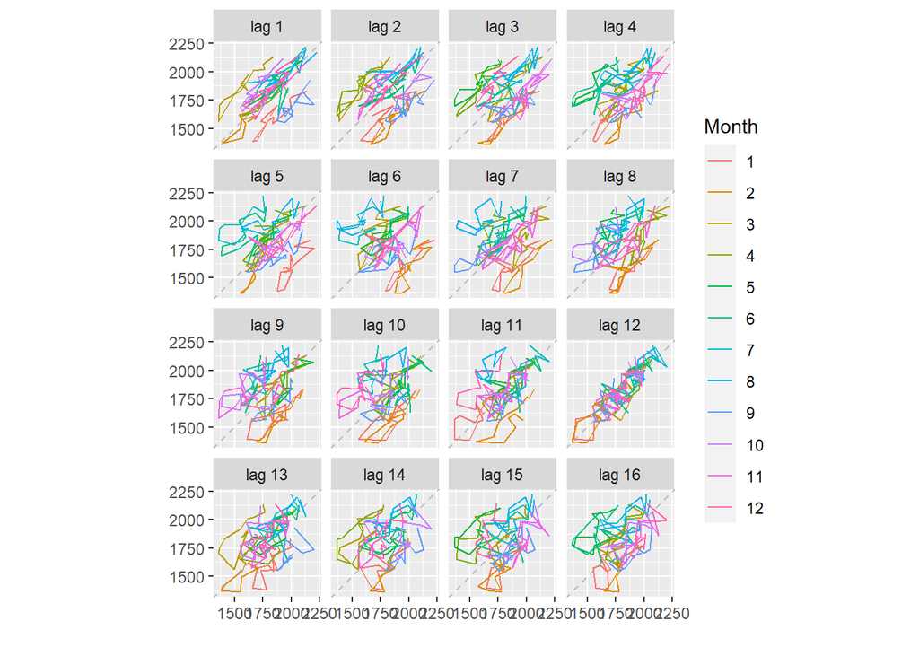

```r
# the forecast package contains the gglagplot() function, which will provide a faceted plot
# containing different lags
gglagplot(amtrak.ts,
          #set.lags = c(1, 12) # the set.lags argument allows specific lags to be supplied
          )
```

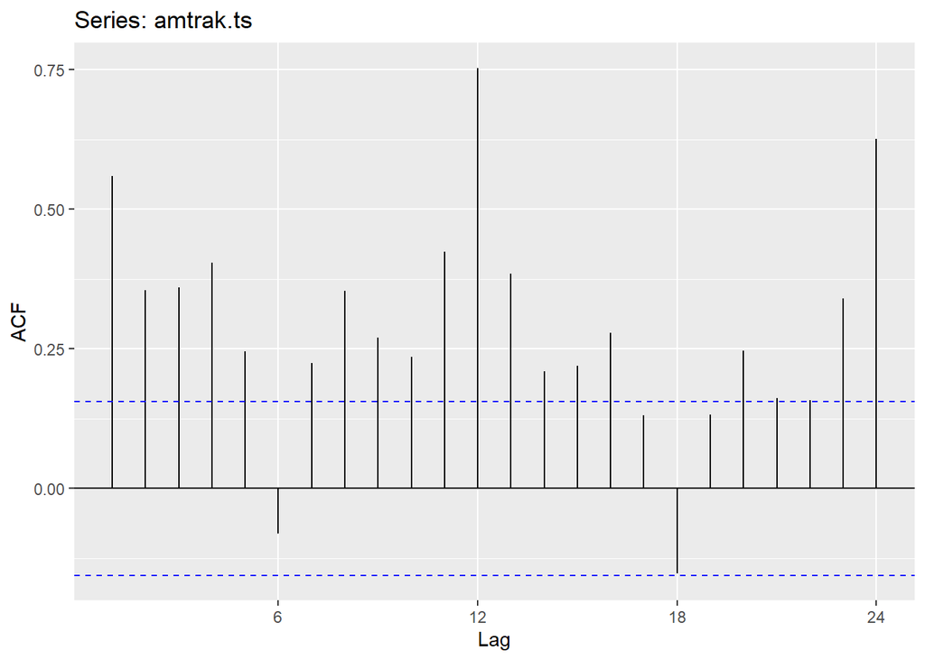

```r
# the forecast package also contains the ggAcf() function, which plots autocorrelation. When
# lagged values lie outside the error bars, they are considered significant. In general,
# white noise data (i.e. data without seasonality) would be expected to lie within the error
# bars 95% of the time.
ggAcf(amtrak.ts)
```

## Exponential Smoothing

A further elaboration of moving average smoothing is *exponential smoothing*. Rather than a parameter *w* to set the size of the window over which values are averaged, exponential smoothing uses a parameter *alpha*, which is an exponentially decaying function across all values in the time series. By varying the value of *alpha* between 0 and 1, greater priority can be given to more recent values (a value close to 1 indicates priority given to most recent values).

*Simple exponential smoothing*, similar to naive forecasting and trailing moving average forecasting, will forecast a horizontal line.

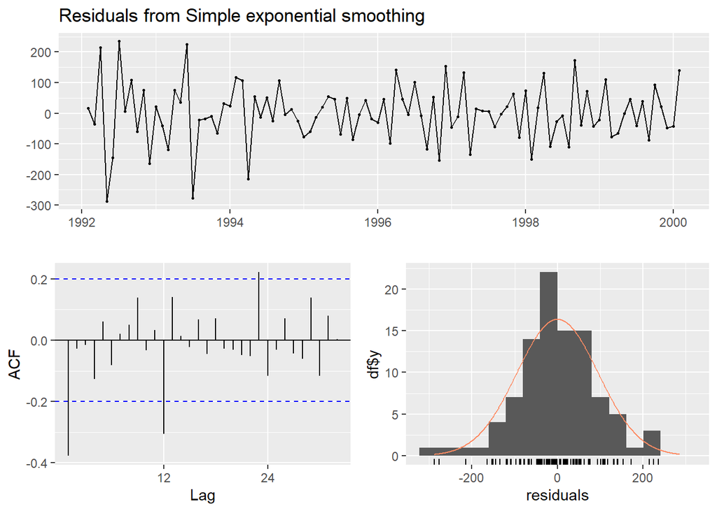

```
##
##  Ljung-Box test
##
## data:  Residuals from Simple exponential smoothing
## Q* = 34.165, df = 19, p-value = 0.01757
##
## Model df: 0.   Total lags used: 19
```

```r
diff.twice <- diff(diff(amtrak.ts, lag = 12), lag = 1) # lag twice to remove trend and seasonality

train.twice <- window(diff.twice, end = c(1991, length(diff.twice) - 36))

# the ses() function in forecast performs simple exponential smoothing
train.ses <- ses(train.twice,
                 alpha = 0.2, # alpha can be set manually
                 h = 36)

checkresiduals(train.ses) # the checkresiduals() function in forecast provides useful plots of residuals, as well as the Ljung-Box test statistic.
```

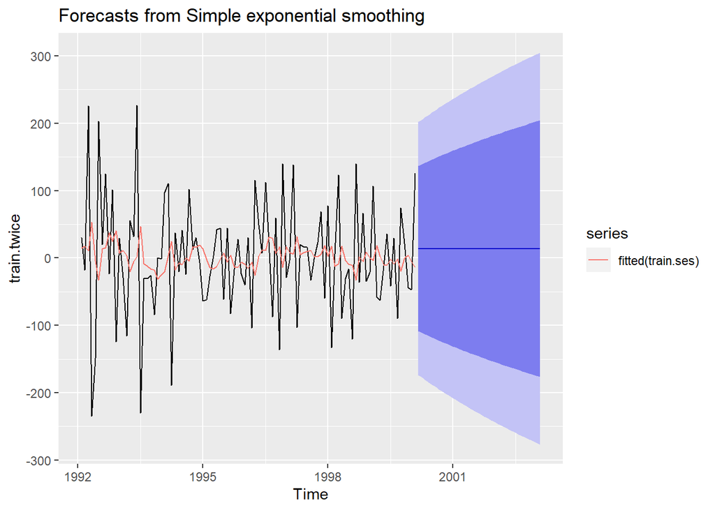

```r
autoplot(train.ses) +
  autolayer(fitted(train.ses))
```

## Advanced Exponential Smoothing

Exponential smoothing can be adapted for data with both trend and seasonality, in order to create more accurate forecasts. In order to learn more about the precise modalities, please consult the course textbook, pp. 90-98. In general, it is important to know that **error**, **trend** and **seasonality** can all be modelled differently:

- Error can be additive or multiplicative (A or M)
- Trend can be none, additive or damped (N, A or Ad)
- Seasonality can be none, additive or multiplicative (N, A or M)

The `ets()` function in the `forecast` package (which stands both for *error, trend and seasonality*, as well as *ExponenTial Smoothing*), will perform a grid search across all possible combinations of these models, and use optimisation to find the best model and the best parameters for that model. Alternatively, a model can be specified using the `model =` argument, supplying a string of relevant models, e.g. “ANN”.

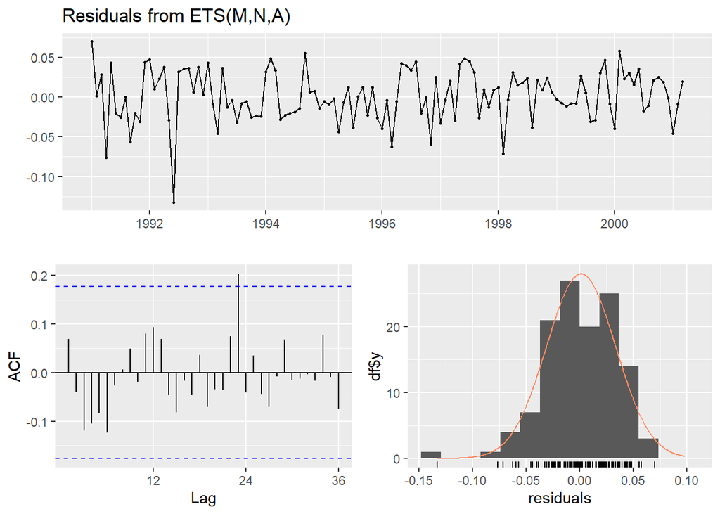

```
##
##  Ljung-Box test
##
## data:  Residuals from ETS(M,N,A)
## Q* = 20.578, df = 24, p-value = 0.6635
##
## Model df: 0.   Total lags used: 24
```

```r
train.ets <- ets(train.ts) # the ets() function picks the best model
ets.fc <- forecast(train.ets, h = 36) # to obtain forecast values we use the forecast() function

checkresiduals(ets.fc)
```

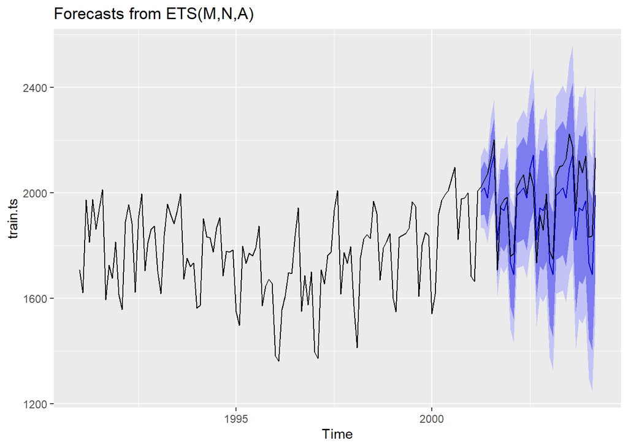

```r
autoplot(ets.fc) +
  autolayer(amtrak.ts, colour = FALSE) +
  theme(legend.position = "none")
```

```r
accuracy(ets.fc, amtrak.ts)
```

```
##                    ME     RMSE      MAE        MPE     MAPE      MASE
## Training set  1.98570 56.86248 45.21332 0.02883941 2.576978 0.5480937
## Test set     49.72735 88.62810 73.96379 2.39118826 3.707185 0.8966182
##                    ACF1 Theil's U
## Training set 0.06113138        NA
## Test set     0.65425349 0.5135193
```

```r
accuracy(snaive(train.ts, h = 36), amtrak.ts)
```

```
##                    ME     RMSE      MAE       MPE     MAPE     MASE      ACF1
## Training set 13.93991 99.26557 82.49196 0.5850656 4.715251 1.000000 0.6400044
## Test set     54.72961 95.62433 84.09406 2.6527928 4.247656 1.019421 0.6373346
##              Theil's U
## Training set        NA
## Test set     0.5532435
```

### Task

The file `ApplianceShipments.csv` contains the series of quarterly shipments (in millions of USD) of US household appliances between 1985 and 1989.

1. Create a time series object from the data and produce a well-formatted plot.

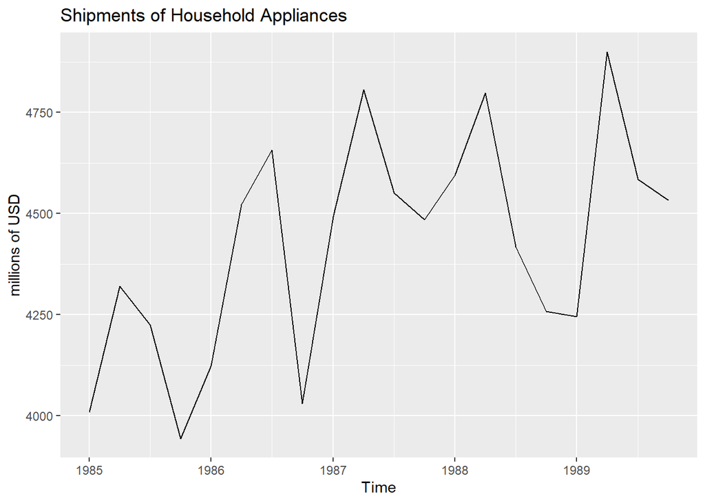

```r
aps <- read.csv("data/ApplianceShipments.csv")
aps.ts <- ts(aps[,-c(1, 3, 4)], start = c(1985, 1), frequency = 4)
autoplot(aps.ts, ylab = "millions of USD", main = "Shipments of Household Appliances")
```

2. Use different exploratory methods to check the data for trend and seasonality. Which method of forecasting would be most suitable to this data?

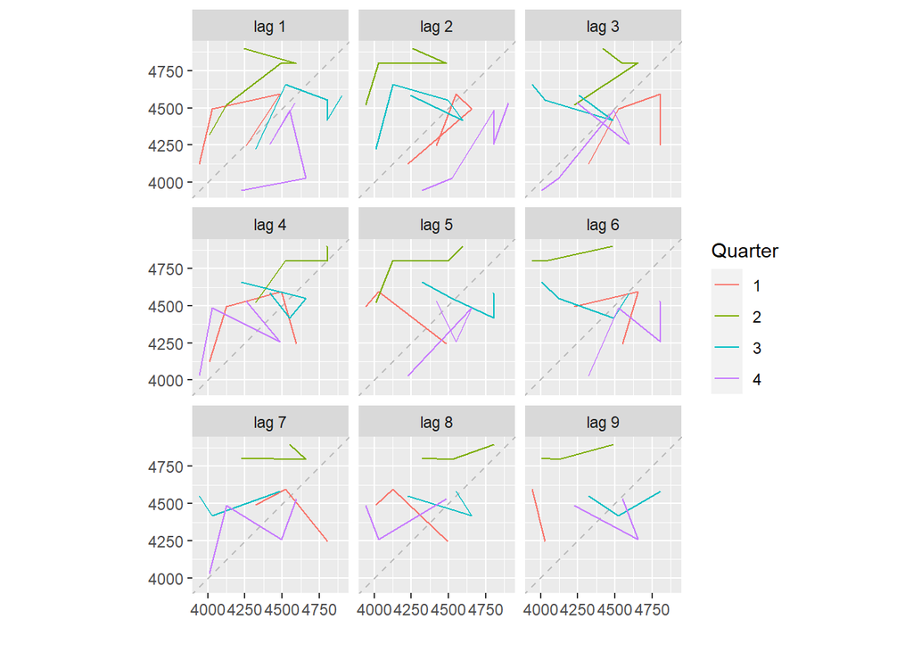

```r
gglagplot(aps.ts)
```

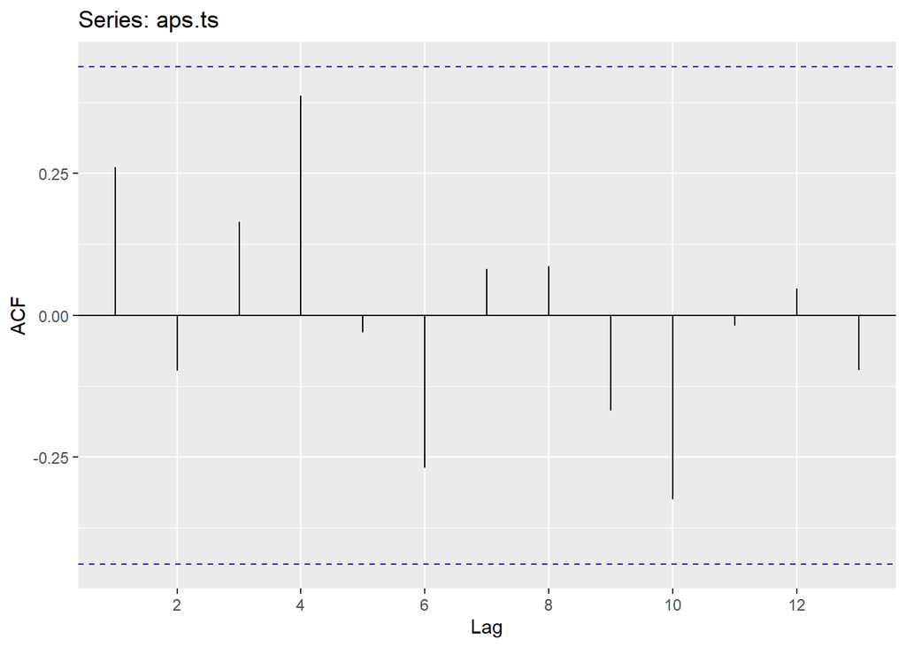

```r
ggAcf(aps.ts)
```

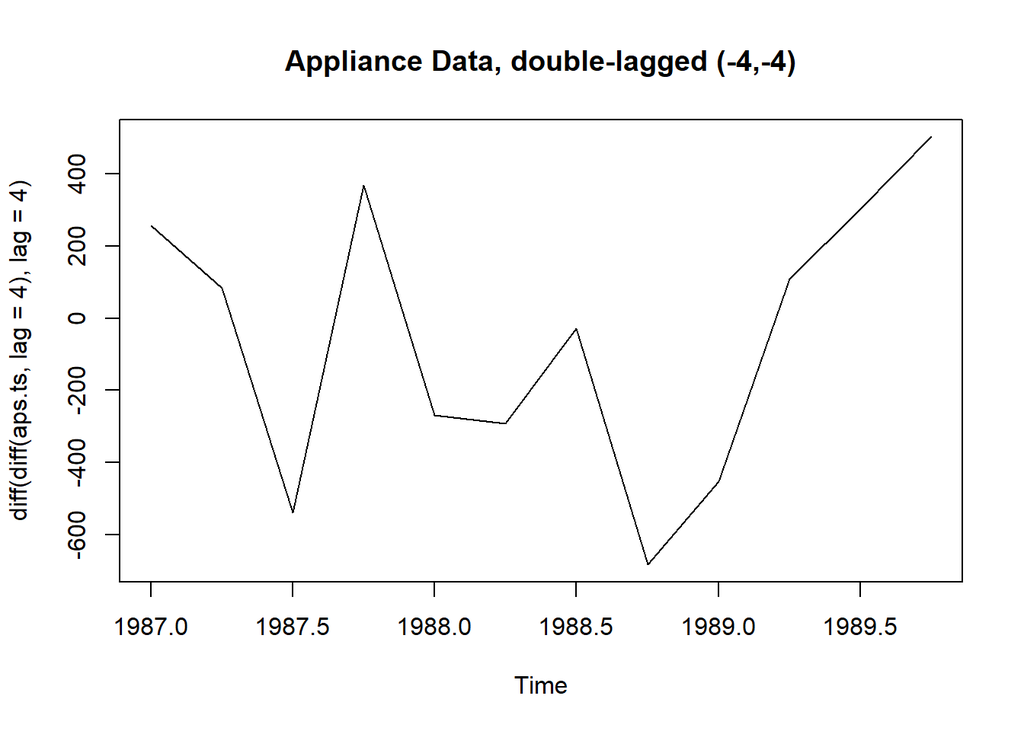

```r
plot(diff(diff(aps.ts, lag = 4), lag = 4), main = "Appliance Data, double-lagged (-4,-4)")
```

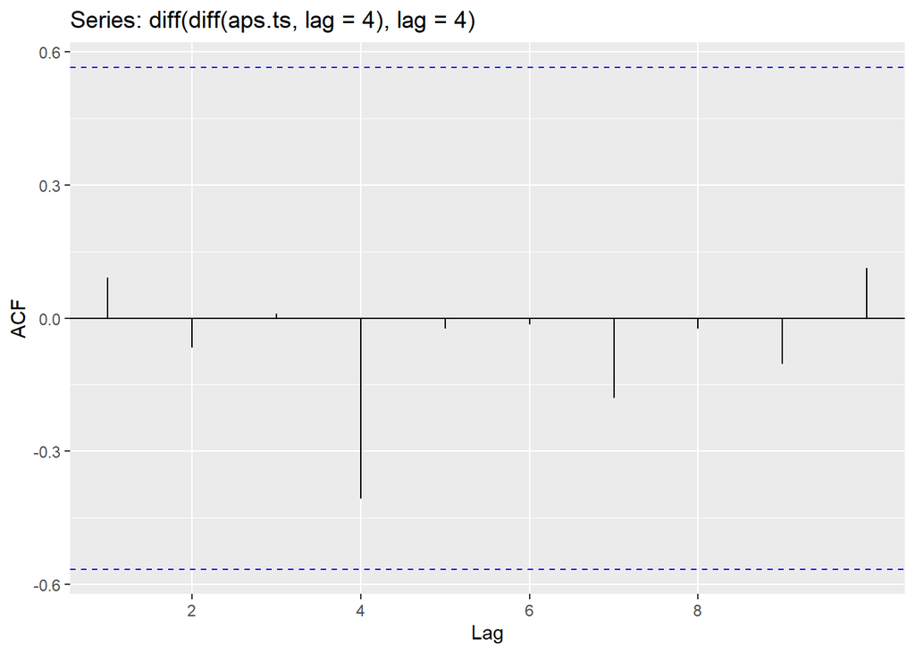

```r
ggAcf(diff(diff(aps.ts, lag = 4), lag = 4))
```

*Exponential smoothing with trend and seasonality (Holt-Winters)*

3. Create a moving average time plot of the data, with a window span, *w*, of 4.

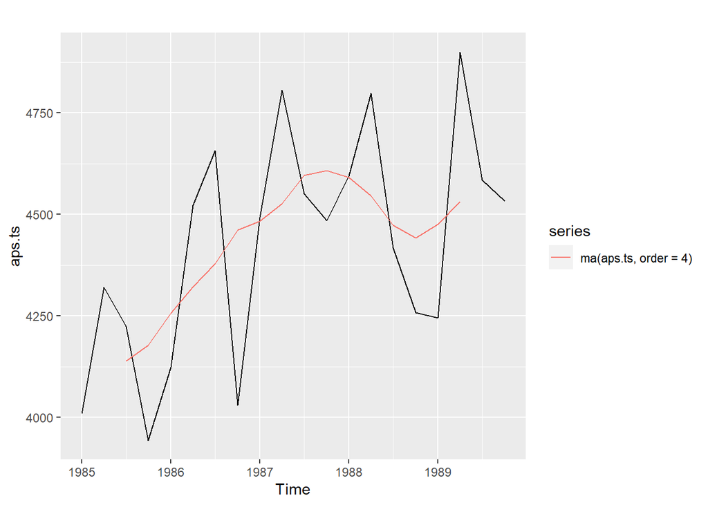

```r
autoplot(aps.ts) +
  autolayer(ma(aps.ts, order = 4))
```

4. Using the last four quarters as a validation period, use the `ets()` function to run the a model as specified in the answer to question b. Plot a time plot of the predicted values against actual values. Check the residuals of the model, and compare the accuracy with a seasonal naive model.

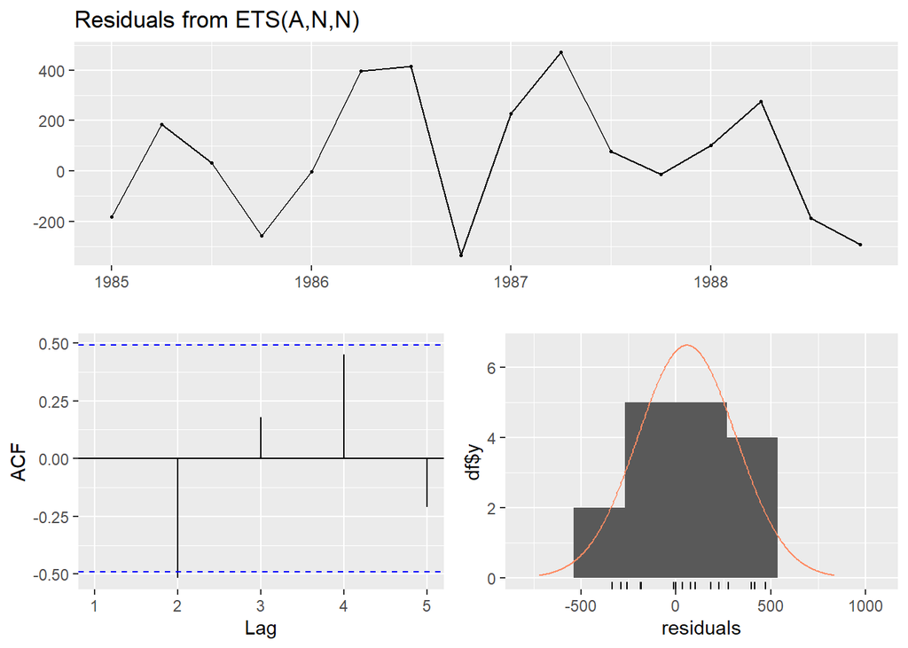

```
##
##  Ljung-Box test
##
## data:  Residuals from ETS(A,N,N)
## Q* = 6.207, df = 3, p-value = 0.102
##
## Model df: 0.   Total lags used: 3
```

```r
aps.train <- subset(aps.ts, end = length(aps.ts) - 4)
aps.ets <- ets(aps.train,
               #model = "AAA"
               )
aps.fc <- forecast(aps.ets, h = 4)

checkresiduals(aps.fc)
```

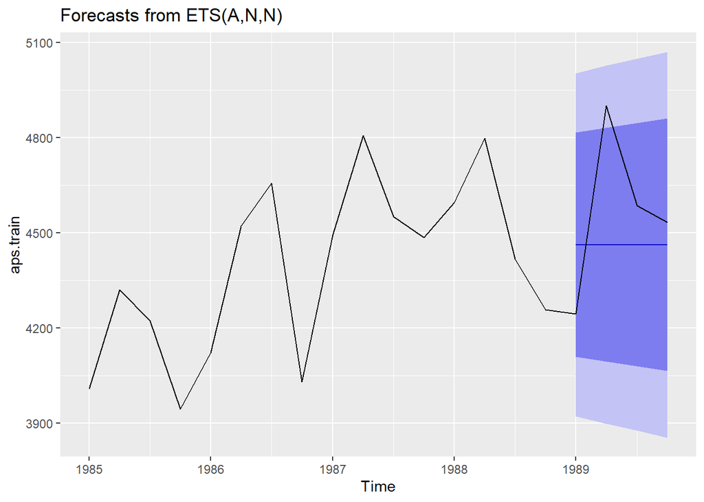

```r
autoplot(aps.fc) +
  autolayer(aps.ts, colour = FALSE) +
  theme(legend.position = "none")
```

```r
accuracy(aps.fc, aps.ts)
```

```
##                     ME     RMSE      MAE      MPE     MAPE    MASE         ACF1
## Training set  57.12038 257.9490 215.6914 1.027569 4.879249 1.02751  0.003441851
## Test set     102.96239 254.1908 211.8562 2.001663 4.566888 1.00924 -0.469374395
##              Theil's U
## Training set        NA
## Test set     0.6390865
```

```r
accuracy(snaive(aps.train, h = 4), aps.ts)
```

```
##                    ME     RMSE      MAE       MPE     MAPE     MASE       ACF1
## Training set 130.9167 252.3287 209.9167 2.8592405 4.665890 1.000000 0.08095064
## Test set      48.5000 243.1820 223.5000 0.8867438 5.009241 1.064708 0.05467639
##              Theil's U
## Training set        NA
## Test set      0.436126
```